# R Assignment - Estimation

Edwin Lo, GWU Intro to Data Science DATS 6101

2022-02-20

# HW Assignment - Estimation

This exercise uses the graduate school admissions dataset from the applicants to a higher-ed institute. The dataset is LogRegAdmit.csv.  
The variables in the dataset are:

- `admit`: 0 or 1 (False or True)
- `gre`: gre score
- `gpa`: grade point average at undergraduate level
- `rank`: the ranking of the applicant’s undergraduate institute, 1, 2, 3, or 4

## Grad School Admissions

### Question 1

**After importing the dataset as Adata, check the structure. Make sure admit and rank are stored as factors, instead of numeric or integers. (Hint: Use as.factor() function or factor() function).**

```r
Adata <- read.csv(file='LogRegAdmit.csv',
                  header=T,
                  sep=',',
                  fill=T,
                  strip.white=T,
                  blank.lines.skip=T,
                  colClasses=c('admit'='factor', 'rank'='factor'))
rmarkdown::paged_table(head(Adata, n=5))
```

|  | admit | gre | gpa | rank |
| --- | --- | --- | --- | --- |
| 1 | 0 | 380 | 3.61 | 3 |
| 2 | 1 | 660 | 3.67 | 3 |
| 3 | 1 | 800 | 4.00 | 1 |
| 4 | 1 | 640 | 3.19 | 4 |
| 5 | 0 | 520 | 2.93 | 4 |

### Question 2

**Construct t-intervals for the gre and gpa data for all applicants at 0.80 level and 0.99 level.**

```r
gre.mean <- mean(Adata$gre)
gre.sd <- sd(Adata$gre)
gpa.mean <- mean(Adata$gpa)
gpa.sd <- sd(Adata$gpa)

n <- nrow(Adata)
df <- n-1

# I do understand we can throw in a list of probs, but I wish to do this way for
# the sake of brevity.
# For GRE 80% confidence
gre.error80 <- qt(p=0.9, df=df) * gre.sd/sqrt(n)
gre.min80 <- gre.mean - gre.error80
gre.max80 <- gre.mean + gre.error80

# For GRE 99% confidence
gre.error90 <- qt(0.995, df=df) * gre.sd/sqrt(n)
gre.min90 <- gre.mean - gre.error90
gre.max90 <- gre.mean + gre.error90

# For GPA 80% confidence
gpa.error80 <- qt(p=0.9, df=df) * gpa.sd/sqrt(n)
gpa.min80 <- gpa.mean - gpa.error80
gpa.max80 <- gpa.mean + gpa.error80

# For GPA 99% confidence
gpa.error90 <- qt(0.995, df=df) * gpa.sd/sqrt(n)
gpa.min90 <- gpa.mean - gpa.error90
gpa.max90 <- gpa.mean + gpa.error90
```

| Var | 80% Min | 80% Max | 99% Min | 99% Max |
| --- | --- | --- | --- | --- |
| GRE | 580.286 | 595.114 | 572.751 | 602.649 |
| GPA | 3.365 | 3.414 | 3.341 | 3.439 |

### Question 3

**Repeat the same calculation for gre in Question 2 but for admitted (1) and rejected (0) separately. (You can subset them first.) Between the admitted and rejected, does the two intervals overlap at 0.80 level? And at 0.99 level?**

```r
library(tidyverse)
Adata.admitted <- Adata %>% filter(admit==1)
Adata.rejected <- Adata %>% filter(admit==0)

# Admitted GRE
admitted.gre.mean <- mean(Adata.admitted$gre)
admitted.gre.sd <- sd(Adata.admitted$gre)
admitted.n <- nrow(Adata.admitted)
admitted.df <- admitted.n - 1

admitted.gre.error80 <- qt(0.9, df=admitted.df) * admitted.gre.sd/sqrt(admitted.n)
admitted.gre.min80 <- admitted.gre.mean - admitted.gre.error80
admitted.gre.max80 <- admitted.gre.mean + admitted.gre.error80

admitted.gre.error90 <- qt(0.995, df=admitted.df) * admitted.gre.sd/sqrt(admitted.n)
admitted.gre.min90 <- admitted.gre.mean - admitted.gre.error90
admitted.gre.max90 <- admitted.gre.mean + admitted.gre.error90

# Rejected GRE
rejected.gre.mean <- mean(Adata.rejected$gre)
rejected.gre.sd <- sd(Adata.rejected$gre)
rejected.n <- nrow(Adata.rejected)
rejected.df <- rejected.n - 1

rejected.gre.error80 <- qt(0.9, df=rejected.df) * rejected.gre.sd/sqrt(rejected.n)
rejected.gre.min80 <- rejected.gre.mean - rejected.gre.error80
rejected.gre.max80 <- rejected.gre.mean + rejected.gre.error80

rejected.gre.error90 <- qt(0.995, df=rejected.df) * rejected.gre.sd/sqrt(rejected.n)
rejected.gre.min90 <- rejected.gre.mean - rejected.gre.error90
rejected.gre.max90 <- rejected.gre.mean + rejected.gre.error90
```

| Var | 80% Min | 80% Max | 99% Min | 99% Max |
| --- | --- | --- | --- | --- |
| Admitted GRE | 606.45 | 631.345 | 593.628 | 644.168 |
| Rejected GRE | 564.181 | 582.193 | 555.002 | 591.372 |

There is no overlap between accepted and rejected sets at any level.

### Question 4

**Make (box-) plots showing the gre distribution among applicants from different school rankings for the admitted and rejected separately. Please use ggplot for this. The x-variable should be rank, and the y-variable should be gre.**

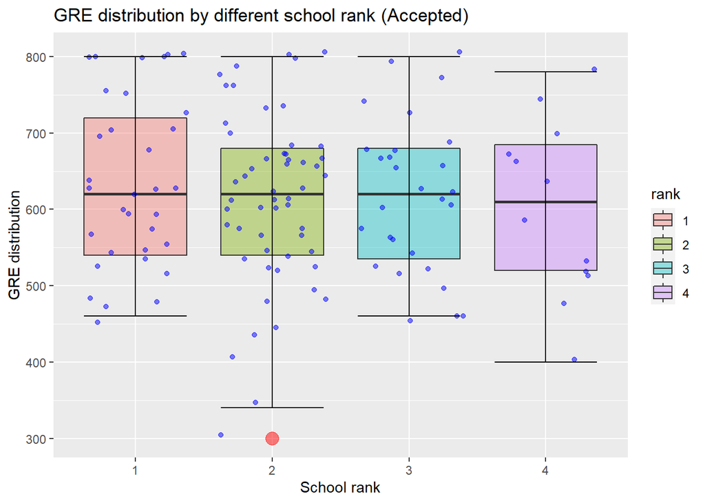

```r
ggplot(Adata.admitted, aes(x=rank, y=gre)) +
geom_boxplot(aes(fill=rank), alpha=0.4, outlier.color='red', outlier.alpha=0.5, outlier.size=4.2) +
  geom_jitter(color='blue', alpha=0.5)+
stat_boxplot(geom ='errorbar')+
xlab('School rank') +
ylab('GRE distribution') +
ggtitle('GRE distribution by different school rank (Accepted)')
```

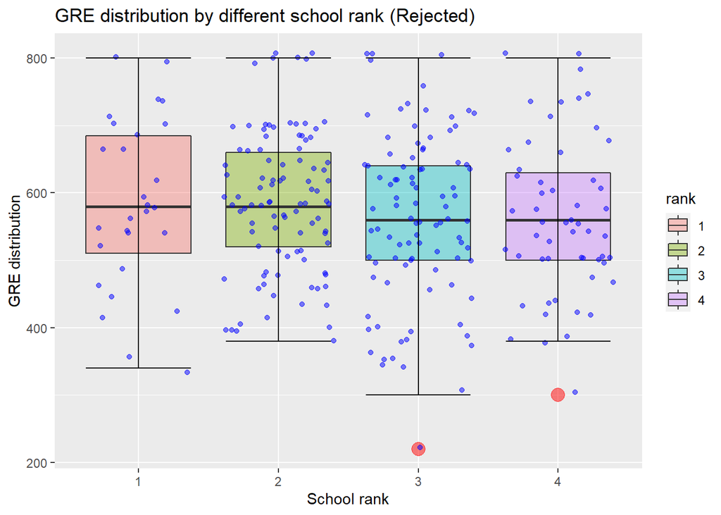

```r
ggplot(Adata.rejected, aes(x=rank, y=gre)) +
geom_boxplot(aes(fill=rank), alpha=0.4, outlier.color='red', outlier.alpha=0.5, outlier.size=4.2) +
  geom_jitter(color='blue', alpha=0.5)+
stat_boxplot(geom ='errorbar')+
xlab('School rank') +
ylab('GRE distribution') +
ggtitle('GRE distribution by different school rank (Rejected)')
```

### Question 5

**Repeat Question 2 and Question 3 for gpa. Do the two groups have t-intervals overlap at 0.80 level? At 0.99 level?**

```r
# Admitted
admitted.gpa.mean <- mean(Adata.admitted$gpa)
admitted.gpa.sd <- sd(Adata.admitted$gpa)

# 80% Confidence
admitted.gpa.error80 <- qt(0.9, df=admitted.df) * admitted.gpa.sd/sqrt(admitted.n)
admitted.gpa.min80 <- admitted.gpa.mean - admitted.gpa.error80
admitted.gpa.max80 <- admitted.gpa.mean + admitted.gpa.error80

# 99% Confidence
admitted.gpa.error99 <- qt(0.995, df=admitted.df) * admitted.gpa.sd/sqrt(admitted.n)
admitted.gpa.min99 <- admitted.gpa.mean - admitted.gpa.error99
admitted.gpa.max99 <- admitted.gpa.mean + admitted.gpa.error99

# Rejected
# 80% Confidence
rejected.gpa.mean <- mean(Adata.rejected$gpa)
rejected.gpa.sd <- sd(Adata.rejected$gpa)

# 80% Confidence
rejected.gpa.error80 <- qt(0.9, df=rejected.df) * rejected.gpa.sd/sqrt(rejected.n)
rejected.gpa.min80 <- rejected.gpa.mean - rejected.gpa.error80
rejected.gpa.max80 <- rejected.gpa.mean + rejected.gpa.error80

# 99% Confidence
rejected.gpa.error99 <- qt(0.995, df=rejected.df) * rejected.gpa.sd/sqrt(rejected.n)
rejected.gpa.min99 <- rejected.gpa.mean - rejected.gpa.error99
rejected.gpa.max99 <- rejected.gpa.mean + rejected.gpa.error99
```

| Var | 80% Min | 80% Max | 99% Min | 99% Max |
| --- | --- | --- | --- | --- |
| Admitted GPA | 3.447 | 3.532 | 3.403 | 3.575 |
| Rejected GPA | 3.314 | 3.373 | 3.284 | 3.403 |

There is no overlap between accepted and rejected sets at any level.

### Question 6

**Repeat Question 4 for gpa. Make (box-) plots showing the gpa distribution among applicants from different school rankings for the admitted and rejected separately. Again, use ggplot.**

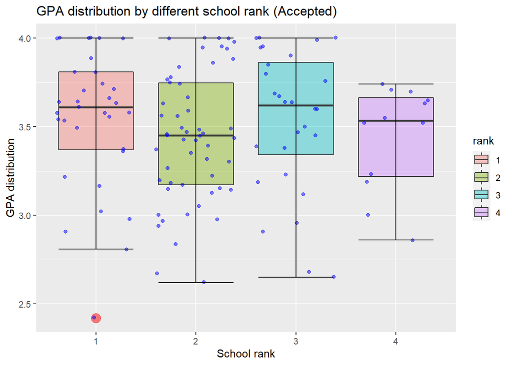

```r
library(ggiraph)
ggplot(Adata.admitted, aes(x=rank, y=gpa)) +
geom_boxplot(aes(fill=rank), alpha=0.4, outlier.color='red', outlier.alpha=0.5, outlier.size=4.2) +
geom_jitter(color='blue', alpha=0.5)+
stat_boxplot(geom ='errorbar')+
xlab('School rank') +
ylab('GPA distribution') +
ggtitle('GPA distribution by different school rank (Accepted)')
```

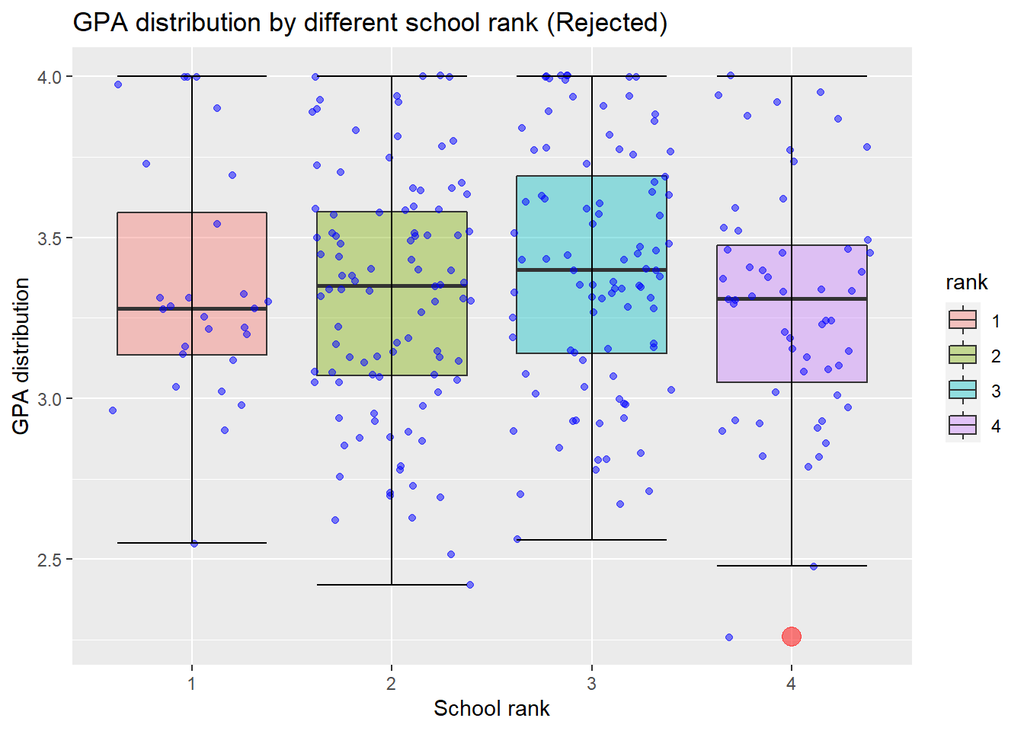

```r
ggplot(Adata.rejected, aes(x=rank, y=gpa)) +
geom_boxplot(aes(fill=rank), alpha=0.4, outlier.color='red', outlier.alpha=0.5, outlier.size=4.2) +
  geom_jitter(color='blue', alpha=0.5)+
stat_boxplot(geom ='errorbar')+
xlab('School rank') +
ylab('GPA distribution') +
ggtitle('GPA distribution by different school rank (Rejected)')
```

### Question 7

**As EDA from the charts and the t-interval calculations you produced, do you observe any potential effects between gre/gpa/rank on admissions? Explain briefly.**

I wish to also add this plot, which I believe would add more information while drawing conclusion.

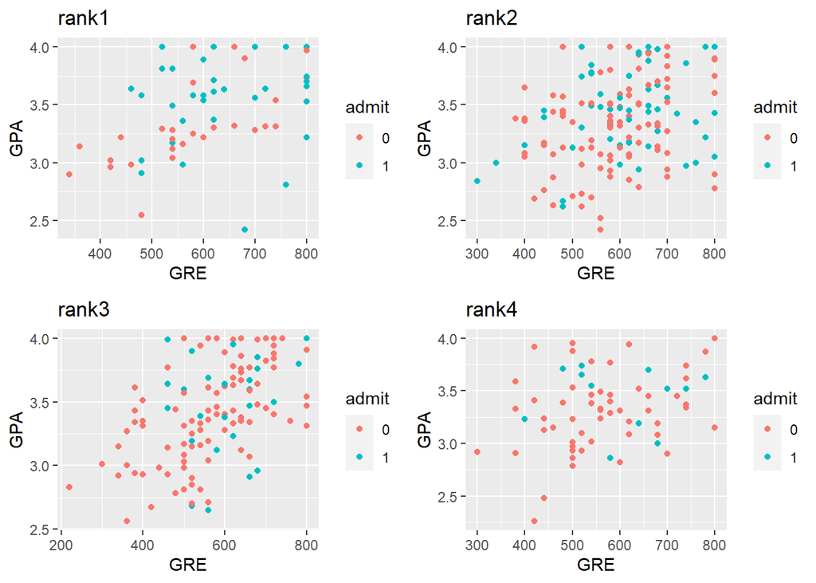

```r
rank1 <- Adata %>% filter(rank==1)
rank2 <- Adata %>% filter(rank==2)
rank3 <- Adata %>% filter(rank==3)
rank4 <- Adata %>% filter(rank==4)

make_plot = function(x, label)
{
  p <- ggplot(x, aes(x=gre, y=gpa, color=admit))+
       geom_point()+
       xlab('GRE')+
       ylab('GPA')+
       ggtitle(label)
  return(p)
}

p1 <- make_plot(rank1, 'rank1')
p2 <- make_plot(rank2, 'rank2')
p3 <- make_plot(rank3, 'rank3')
p4 <- make_plot(rank4, 'rank4')

library(gridExtra)
grid.arrange(p1, p2, p3, p4, nrow=2)
```

Generally speaking, all t-interval indicate for admitted candidates, the lower bound at 0.8 level is higher compared to those who were rejected. It appears boxplots support the hypothesis by having the second quartile relatively higher compared to those who were rejected.

However, after thoroughly looking at the scatter points in the boxplots and from the above figure, it appears that many candidates who still had achieved high GPA, and GRE scores were not offered a place. This underlines the fact that the admissions process involves considering several factors that weren’t included in the data set such as the Letters of recommendation, publications, professional exposure, along with the marks for making a decision instead of GPA, and GRE being the sole factors.